# GEOG 6000 Lab 08b Visualizing spatial Data in R

Simon Brewer and Blake Vernon

9/2/2020

The following files will be used in this lab, all available on Canvas:

- Climate dataset for Western North America: *WNAclimate.csv*
- New York state polygon data in a shapefile: *NY_Data.zip*
- A NetCDF file of global monthly air temperature: *air.mon.ltm.nc*

You will need to download these files from Canvas, and move them from your `Downloads` folder to the `datafiles` folder that you made previously. Make sure to unzip the zip files so that R can access the content. Note that on Windows, you will need to right-click on the file and select ‘Extract files’.

You will also need to make sure the following packages are installed on your computer:

```r
pkgs <- c("ggplot2",
          "mapview",
          "raster",
          "RColorBrewer"
          "sf",
          "tmap",
          "viridis")

install.packages(pkgs)
```

```r
library(mapview)
library(raster)
library(RColorBrewer)
library(sf)
library(tmap)
library(viridis)
```

# Static plots with **tmap**

[`tmap`](https://mtennekes.github.io/tmap/) is built on top of `ggplot2` and works in a similar way by building a series of layers with map geometries and elements. We start by using `tm_shape()` to identify the spatial object to be used, and then geometries are added, including filled polygons, borders, legends, etc.

## Polygon data

We’ll start by making some maps based on the NY shapefile. Start by loading this, then extract only the polygons belonging to Syracuse.

```r
NY8 <- st_read(dsn = "../datafiles/NY_data/NY8_utm18.shp",
               layer = "NY8_utm18",
               drivers = "ESRI Shapefile")
```

```
## options:        ESRI Shapefile
```

```r
Syracuse <- NY8[NY8$AREANAME == "Syracuse city", ]
```

First, let’s make a simple map showing the polygon outlines using `tm_borders()`:

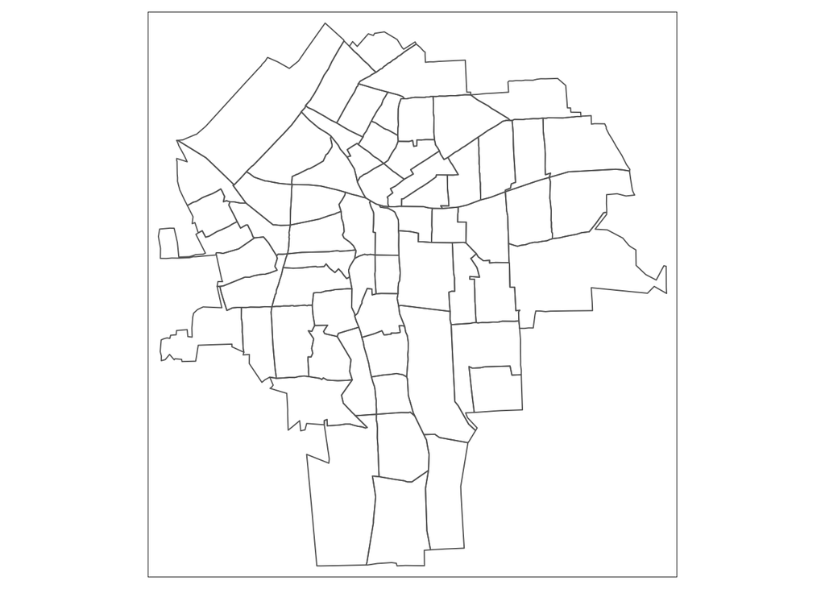

```r
tm_shape(Syracuse) + tm_borders()
```

The function `tm_fill()` can be used to create a thematic map by using one of the attributes in the Syracuse data set (`POP8`). Note that this automatically adds a legend within the frame of the figure:

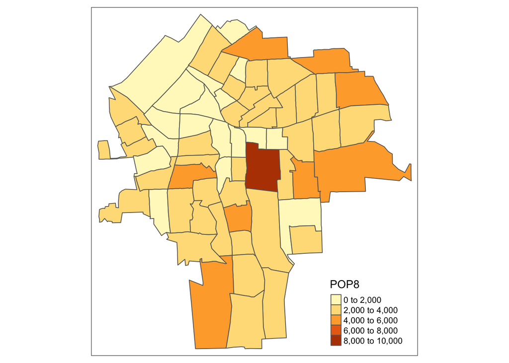

```r
tm_shape(Syracuse) +
  tm_borders() +
  tm_fill("POP8")
```

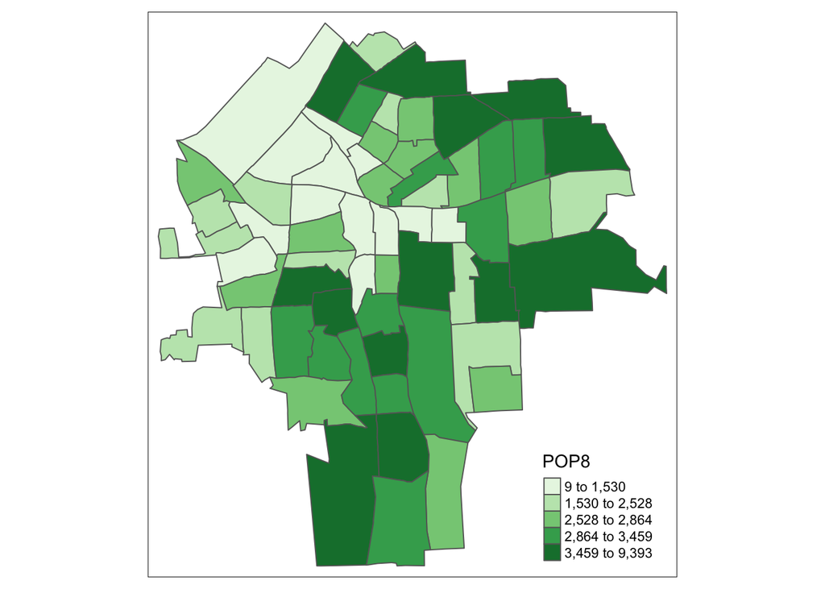

```r
tm_shape(Syracuse) +
  tm_borders() +
  tm_fill("POP8", palette = "Greens", style = "quantile")
```

Other map elements can be added. Here we add a longitude/latitude graticule with `tm_graticules()`, a north arrow and a line of text with the date the map was made.

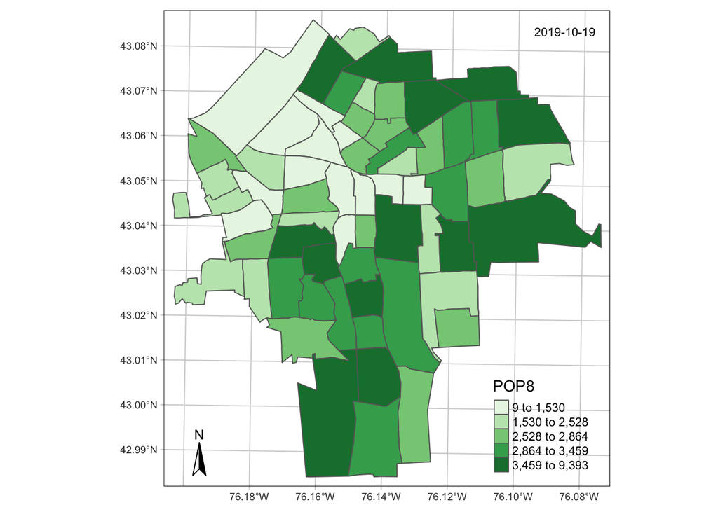

```r
tm_shape(Syracuse) +
  tm_graticules(col = "lightgray") +
  tm_borders() +
  tm_fill("POP8", palette = "Greens", style = "quantile") +
  tm_compass(position = c("left", "bottom")) +
  tm_credits("2019-10-19", position = c("right", "top"))
```

## Poitn data

We’ll next make some maps with the Western North American site data. As before, we load the data, then convert to an `sf` object. We also load the shapefile of country outlines:

```r
wna_climate <- read.csv("../datafiles/WNAclimate.csv")

wna_climate <- st_as_sf(wna_climate,
                        coords = c("LONDD", "LATDD"),
                        crs = 4326)

countries <- st_read("../datafiles/ne_50m_admin_0_countries/ne_50m_admin_0_countries.shp",
                     quiet = TRUE)
```

Individual symbols can be plotted on a color scale using `tm_symbols`.

```r
tm_shape(wna_climate) + tm_symbols(col="Jan_Tmp")
```

[output not shown]

This takes the same arguments as `tm_fill()` for the color palette. We’ll use a red to blue color scale from **RColorBrewer**. The minus sign before the palette name reverses the order of the colors. As there is a large amount of overlap between the sites, we also add an alpha level to make the symbols transparent.

```r
tm_shape(wna_climate) +
  tm_symbols(col="Jan_Tmp", alpha = 0.5, palette = "-RdBu")
```

[output not shown]

We’ll next add country boundaries from the Natural Earth shapefile loaded earlier. Note that as this is a different spatial object, we have to use `tm_shape()` a second time to reference this, then use `tm_borders()` to add the lines.

```r
tm_shape(wna_climate) +
  tm_symbols(col="Jan_Tmp", alpha = 0.75, palette = "-RdBu") +
  tm_shape(countries) + tm_borders(col="gray")
```

[output not shown]

```r
tm_shape(wna_climate) +
  tm_symbols(col="Jan_Tmp", alpha = 0.75, palette = "-RdBu") +
  tm_shape(countries) + tm_borders(col="gray") + tm_style("cobalt")
```

[output not shown]

## Raster data

In the final example, we’ll make figures using the global air temperature dataset. Start by re-reading the data (we also change the name of the layer, to reduce the amount of typing later on…).

```r
air_temp <- rotate(raster("../datafiles/air.mon.ltm.nc", varname = "air"))

air_temp
```

```
## class      : RasterLayer
## dimensions : 73, 144, 10512  (nrow, ncol, ncell)
## resolution : 2.5, 2.5  (x, y)
## extent     : -178.75, 181.25, -91.25, 91.25  (xmin, xmax, ymin, ymax)
## crs        : NA
## source     : memory
## names      : Monthly.Long.Term.Mean.Air.Temperature.at.sigma.level.0.995
## values     : -37.77505, 33.58953  (min, max)
## z-value    : 0000-12-30
```

```r
names(air_temp) <- "jan_tmp"

proj4string(air_temp) <- CRS("+init=epsg:4326")
```

Now let’s make a plot using `tm_raster()`, which again takes similar options for color palettes. We’ll also add the country borders.

```r
tm_shape(air_temp) +
  tm_raster(col = "jan_tmp", style="fisher", palette="-RdBu") +
  tm_shape(countries) + tm_borders()
```

[output not shown]

We can improve this a little by moving the color legend outside of the plotting area. We’ll increase the number of color classes to 9, and add a histogram showing the frequency of different values.

```r
tm_shape(air_temp) +
  tm_raster("jan_tmp", style="fisher", palette="-RdBu", legend.hist = TRUE, n = 9) +
  tm_shape(countries) + tm_borders() + tm_layout(legend.outside = TRUE,
                                                 legend.outside.position = "left")
```

[output not shown]